# 05_PCA_K-meansClustering

**The Madelon dataset is a synthetic dataset that was generated for a machine learning competition. It is a high-dimensional dataset, with 500 features and 2,600 data points. It has a highly non-linear structure.**

```python
import pandas as pd
import numpy as np

from sklearn.cluster import KMeans
from sklearn import preprocessing
from sklearn.metrics import silhouette_score
from sklearn.metrics.pairwise import pairwise_distances_argmin
from sklearn.decomposition import PCA
from scipy.stats import skew, kurtosis
from matplotlib import pyplot as plt
```

### 1. Preprocess the data

I normalized the data and removed the first column which is not one of the features of the dataset. I also checked the skewness and kurtosis of each variables and the distributions of the means of features and observations.

```python
madelon_ori = pd.read_csv("madelon.csv")
madelon_ori.head()
```

|  | Unnamed: 0 | V1 | V2 | V3 | V4 | V5 | V6 | V7 | V8 | V9 | ... | V491 | V492 | V493 | V494 | V495 | V496 | V497 | V498 | V499 | V500 |
| --- | --- | --- | --- | --- | --- | --- | --- | --- | --- | --- | --- | --- | --- | --- | --- | --- | --- | --- | --- | --- | --- |
| 0 | 0 | 485 | 477 | 537 | 479 | 452 | 471 | 491 | 476 | 475 | ... | 477 | 481 | 477 | 485 | 511 | 485 | 481 | 479 | 475 | 496 |
| 1 | 1 | 483 | 458 | 460 | 487 | 587 | 475 | 526 | 479 | 485 | ... | 463 | 478 | 487 | 338 | 513 | 486 | 483 | 492 | 510 | 517 |
| 2 | 2 | 487 | 542 | 499 | 468 | 448 | 471 | 442 | 478 | 480 | ... | 487 | 481 | 492 | 650 | 506 | 501 | 480 | 489 | 499 | 498 |
| 3 | 3 | 480 | 491 | 510 | 485 | 495 | 472 | 417 | 474 | 502 | ... | 491 | 480 | 474 | 572 | 454 | 469 | 475 | 482 | 494 | 461 |
| 4 | 4 | 484 | 502 | 528 | 489 | 466 | 481 | 402 | 478 | 487 | ... | 488 | 479 | 452 | 435 | 486 | 508 | 481 | 504 | 495 | 511 |

5 rows × 501 columns

```python
# extract the 500 variables
madelon = madelon_ori.iloc[:,1:]
```

```python
# check for missing values
madelon.info()
```

```
<class 'pandas.core.frame.DataFrame'>
RangeIndex: 2600 entries, 0 to 2599
Columns: 500 entries, V1 to V500
dtypes: int64(500)
memory usage: 9.9 MB
```

```python
# check the skewness and kurtosis of each variable
skewness = []
kurtoses = []

for keys, values in madelon.items():
    skewness.append(skew(np.array(values)))
    kurtoses.append(kurtosis(np.array(values)))

sk_sum = 0
for i in skewness:
    if abs(i) > 0.5:
        sk_sum += 1

kur_sum = 0
for i in kurtoses:
    if abs(i) > 1:
        kur_sum += 1

print(f"Number of skewed variables:\t{sk_sum}\nNumber of kurtic variables:\t{kur_sum}")
```

```
Number of skewed variables:	0
Number of kurtic variables:	0
```

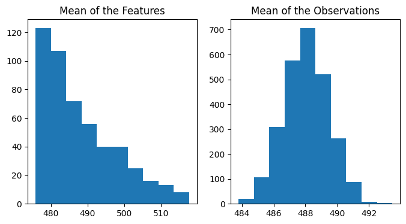

```python
# Check the scale of the features
mean_ft = madelon.mean(0)

# Check the scale of the observations
mean_obs = madelon.mean(1)

# Visualize the scales
plt.figure(figsize = (8,4))

plt.subplot(121)
plt.hist(mean_ft)
plt.title("Mean of the Features")

plt.subplot(122)
plt.hist(mean_obs)
plt.title("Mean of the Observations")
```

```python
# Normalize the data
madelon = pd.DataFrame(preprocessing.normalize(madelon))
madelon.head()
```

|  | 0 | 1 | 2 | 3 | 4 | 5 | 6 | 7 | 8 | 9 | ... | 490 | 491 | 492 | 493 | 494 | 495 | 496 | 497 | 498 | 499 |
| --- | --- | --- | --- | --- | --- | --- | --- | --- | --- | --- | --- | --- | --- | --- | --- | --- | --- | --- | --- | --- | --- |
| 0 | 0.044359 | 0.043628 | 0.049115 | 0.043811 | 0.041341 | 0.043079 | 0.044908 | 0.043536 | 0.043445 | 0.043262 | ... | 0.043628 | 0.043993 | 0.043628 | 0.044359 | 0.046737 | 0.044359 | 0.043993 | 0.043811 | 0.043445 | 0.045365 |
| 1 | 0.044311 | 0.042017 | 0.042201 | 0.044678 | 0.053852 | 0.043577 | 0.048256 | 0.043944 | 0.044494 | 0.043026 | ... | 0.042476 | 0.043852 | 0.044678 | 0.031008 | 0.047063 | 0.044586 | 0.044311 | 0.045137 | 0.046788 | 0.047430 |
| 2 | 0.044479 | 0.049502 | 0.045575 | 0.042743 | 0.040917 | 0.043017 | 0.040369 | 0.043657 | 0.043839 | 0.043565 | ... | 0.044479 | 0.043931 | 0.044935 | 0.059366 | 0.046214 | 0.045757 | 0.043839 | 0.044661 | 0.045575 | 0.045483 |
| 3 | 0.043957 | 0.044964 | 0.046704 | 0.044415 | 0.045330 | 0.043224 | 0.038187 | 0.043407 | 0.045971 | 0.043590 | ... | 0.044964 | 0.043957 | 0.043407 | 0.052382 | 0.041576 | 0.042949 | 0.043499 | 0.044140 | 0.045239 | 0.042217 |
| 4 | 0.044440 | 0.046093 | 0.048480 | 0.044899 | 0.042787 | 0.044164 | 0.036911 | 0.043889 | 0.044715 | 0.042971 | ... | 0.044807 | 0.043981 | 0.041502 | 0.039941 | 0.044623 | 0.046643 | 0.044164 | 0.046276 | 0.045450 | 0.046919 |

5 rows × 500 columns

```python
madelon.describe()
```

|  | 0 | 1 | 2 | 3 | 4 | 5 | 6 | 7 | 8 | 9 | ... | 490 | 491 | 492 | 493 | 494 | 495 | 496 | 497 | 498 | 499 |
| --- | --- | --- | --- | --- | --- | --- | --- | --- | --- | --- | --- | --- | --- | --- | --- | --- | --- | --- | --- | --- | --- |
| count | 2600.000000 | 2600.000000 | 2600.000000 | 2600.000000 | 2600.000000 | 2600.000000 | 2600.000000 | 2600.000000 | 2600.000000 | 2600.000000 | ... | 2600.000000 | 2600.000000 | 2600.000000 | 2600.000000 | 2600.000000 | 2600.000000 | 2600.000000 | 2600.000000 | 2600.000000 | 2600.000000 |
| mean | 0.044050 | 0.044215 | 0.046573 | 0.044198 | 0.045803 | 0.043831 | 0.043935 | 0.043577 | 0.044532 | 0.043781 | ... | 0.044097 | 0.043781 | 0.044462 | 0.045495 | 0.045153 | 0.046700 | 0.043721 | 0.044179 | 0.046490 | 0.044859 |
| std | 0.000594 | 0.002771 | 0.003542 | 0.000826 | 0.003776 | 0.000642 | 0.003692 | 0.000179 | 0.001395 | 0.000683 | ... | 0.001907 | 0.000389 | 0.002165 | 0.011588 | 0.003190 | 0.003443 | 0.000551 | 0.001254 | 0.003381 | 0.002371 |
| min | 0.042168 | 0.034515 | 0.033867 | 0.041475 | 0.032859 | 0.041799 | 0.030574 | 0.042871 | 0.039364 | 0.041594 | ... | 0.037257 | 0.042370 | 0.035947 | 0.009474 | 0.033782 | 0.032327 | 0.041635 | 0.039797 | 0.033212 | 0.036739 |
| 25% | 0.043655 | 0.042382 | 0.044238 | 0.043648 | 0.043306 | 0.043411 | 0.041382 | 0.043458 | 0.043606 | 0.043313 | ... | 0.042767 | 0.043513 | 0.043053 | 0.037089 | 0.042983 | 0.044414 | 0.043366 | 0.043319 | 0.044148 | 0.043269 |
| 50% | 0.044050 | 0.044216 | 0.046588 | 0.044194 | 0.045694 | 0.043827 | 0.043955 | 0.043579 | 0.044515 | 0.043782 | ... | 0.044052 | 0.043783 | 0.044418 | 0.046230 | 0.045097 | 0.046669 | 0.043714 | 0.044177 | 0.046414 | 0.044852 |
| 75% | 0.044444 | 0.046085 | 0.048927 | 0.044749 | 0.048218 | 0.044242 | 0.046314 | 0.043696 | 0.045419 | 0.044245 | ... | 0.045337 | 0.044040 | 0.045879 | 0.053560 | 0.047250 | 0.048966 | 0.044087 | 0.045000 | 0.048739 | 0.046413 |
| max | 0.045920 | 0.055485 | 0.059662 | 0.047179 | 0.062867 | 0.046302 | 0.056024 | 0.044158 | 0.049892 | 0.046208 | ... | 0.050289 | 0.045414 | 0.052169 | 0.083694 | 0.056372 | 0.060448 | 0.045873 | 0.048907 | 0.058637 | 0.054468 |

8 rows × 500 columns

### 2. Describe qualitatively: how does the number of clusters affect the performance of the clustering algorithm on the dataset?

1. Too few clusters may result in underdescribing the data features, i.e. several "true clusters" that are relatively close to each other may be treated as one cluster. So with too few clusters, the model may be defective in differentiating certain clusters. Besides, too few clusters, the meaning of each cluster would be hard to interpret as there may be a mix of different type of data points.
2. Too many clusters may end up with over-differentation, i.e. data points that share a considerable amount of commonalities and that should be considered as one cluster may be assigned to two or more different clusters. Therefore, with too many clusters, the model may be overfitting and too sensitive to noise or outliers. In addition, the large number of clusters may also make it hard to identify the natural groups or patterns in the data, leading to difficulty in understanding the results.

### 3. Generate a plot of the number of clusters k (x-axis) versus the sum of squared distance (SSE) between data points and their assigned centroids (y-axis).

```python
# Define the function for k-means clustering with a list of trail k
def k_means(klist, data, init = "k-means++"):
    inertia = []
    silhouette = []
    for i in klist:
        km = KMeans(n_clusters=i, random_state=117, init = init, n_init="auto").fit(data)
        inertia.append(km.inertia_)
        silhouette.append(silhouette_score(data, km.labels_))
    df = pd.DataFrame({"k":klist, "inertia":inertia, "silhouette":silhouette})
    return df
```

```python
# Calculate the SSE for each choice of k
klist = [4, 8, 16, 32, 64]
df = k_means(klist, madelon)
df
```

|  | k | inertia | silhouette |
| --- | --- | --- | --- |
| 0 | 4 | 8.569503 | 0.043757 |
| 1 | 8 | 8.051793 | 0.035275 |
| 2 | 16 | 7.806155 | 0.021555 |
| 3 | 32 | 7.607546 | 0.013972 |
| 4 | 64 | 7.411223 | 0.008213 |

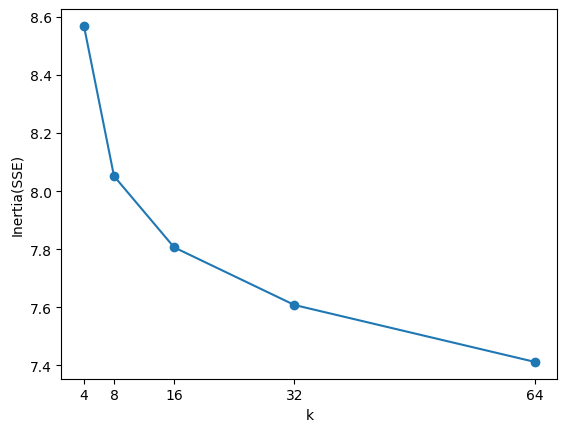

```python
# Plot SSE ~ the value of k
inertia = df[["inertia"]]
plt.plot(klist, inertia, "-o")
plt.xticks(klist)
plt.xlabel("k")
plt.ylabel("Inertia(SSE)")
```

From the list of k values, k = 32 appears to be the optimal number of clusters since it seems like the "turning point" of the elbow plot, i.e. the decrease of SSE between two "k" seems to slow down from k = 32. Although the SSE of k = 64 is smaller than it's of k = 32, the amount of drop doesn't seem to be compensating enough for the doubled number of clusters.

### 4. For k = 8, rerun k-means again with different centroids

I initialized the set of cluster centroids using sampling based on an empirical probability distribution of the points’ contribution to the overall inertia. To set different centroids and see the diffenrece in the results, now I randomly assign centroids.

```python
df2 = k_means(klist, madelon, "random")
df2
```

|  | k | inertia | silhouette |
| --- | --- | --- | --- |
| 0 | 4 | 8.546977 | 0.046196 |
| 1 | 8 | 8.051271 | 0.035400 |
| 2 | 16 | 7.804539 | 0.022100 |
| 3 | 32 | 7.607260 | 0.014507 |
| 4 | 64 | 7.421681 | 0.006425 |

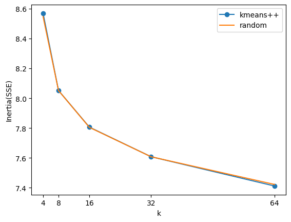

```python
# Compare the results
inertia2 = df2[['inertia']]

plt.plot(klist, inertia, "-o", label="kmeans++")
plt.plot(klist, inertia2, "-", label="random")
plt.xticks(klist)
plt.xlabel("k")
plt.ylabel("Inertia(SSE)")
plt.legend()
```

The elbow plots of the two methods almost overlap with each other. And the decision of the number of k wouldn't change because of the tiny difference, which means the different initializing method influence little on the results of k-means clustering.

### 5. What evaluation metrics can be used to assess the quality of the clusters produced?

More genereally for any dataset, we can use silhouette score to assess the quality of the clusters produced. The value of the silhouette coefﬁcient is between [-1, 1]. A score of 1 denotes the best meaning that the data point i is very compact within the cluster to which it belongs and far away from the other clusters. The worst value is -1. Values near 0 denote overlapping clusters.

### 6. Fit the standardized data with PCA. Then, create a cumulative variance plot – showing the number of components included (x-axis) versus the amount of variance captured (y-axis). Retain at least 75% of the variance

```python
# Fit the PCA model
pca = PCA(n_components = 500).fit(madelon)

# Get the amount of explained variance for each components
var = pca.explained_variance_

# Calculate the cumulative variance explained
var_cum = []
ii = 0

for i in var:
    ii += i
    var_cum.append(ii)
```

```python
# Find the number of components with which the model explains at least 75% of the variance
num = 0
for i in var_cum:
    if i > 0.75 * var_cum[-1]:
        num += 1
        print(f"I would choose {num} components, since they can explain {i/var_cum[-1]} of the variance")
        break
    num += 1
```

```
I would choose 139 components, since they can explain 0.7507143160668056 of the variance
```

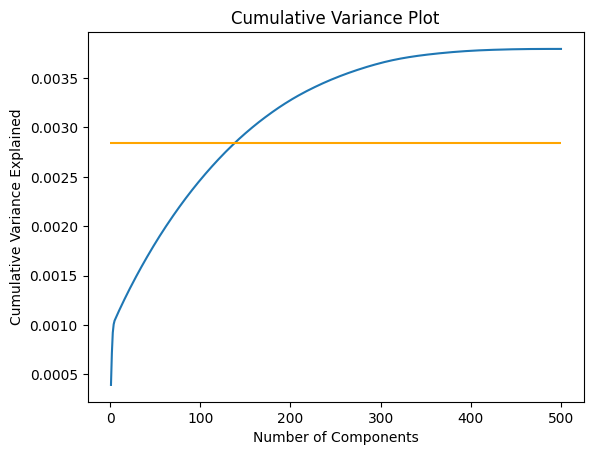

```python
# Plot the cumulative variance plot
plt.plot(np.linspace(1,500,500), var_cum)
plt.hlines(0.75*var_cum[-1], 0, 500, colors="orange")
plt.xlabel("Number of Components")
plt.ylabel("Cumulative Variance Explained")
plt.title("Cumulative Variance Plot")
```

### 7. Perform PCA then plot the transformed data on a graph with the first two principal components as the axes i.e. x = PC 1, y = PC 2

```python
# Extract the components
components = pca.components_[:num,:]

# Transform the data
madelon_trans = np.dot(madelon,np.transpose(components))

# Get the first two components
comp2 = madelon_trans[:,:2]
```

```python
%%javascript
IPython.OutputArea.prototype._should_scroll = function(lines) {
    return false;
}
```

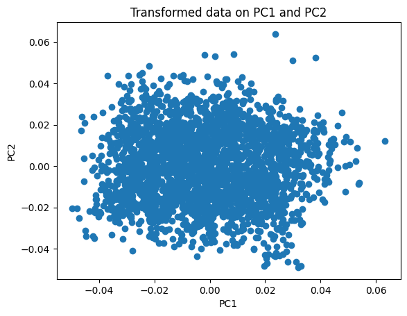

```python
# Scatter plot 1 - transformed data
plt.scatter(comp2[:,0], comp2[:,1])
plt.title("Transformed data on PC1 and PC2")
plt.xlabel("PC1")
plt.ylabel("PC2")
```

### 8. Plot the original data on a graph with the two original variables that have the highest absolute combined loading for PC 1 and PC 2 i.e. maximizing |loading PC1| + |loading PC2|.

```python
# Get the indexes of the two original variables that have the highest absolute combined loadings for PC1 and PC2
abs_loadings1 = abs(components[0])
abs_loadings2 = abs(components[1])

max_cob = 0
for ind1, i in enumerate(abs_loadings1):
    for ind2, ii in enumerate(abs_loadings2):
        if i + ii > max_cob:
            max_cob = i + ii
            indexes = [ind1, ind2]

print(max_cob)
print(indexes)

# Get the corresponding variables
v1 = madelon[indexes[0]]
v2 = madelon[indexes[1]]
```

```
0.8989094864959772
[105, 336]
```

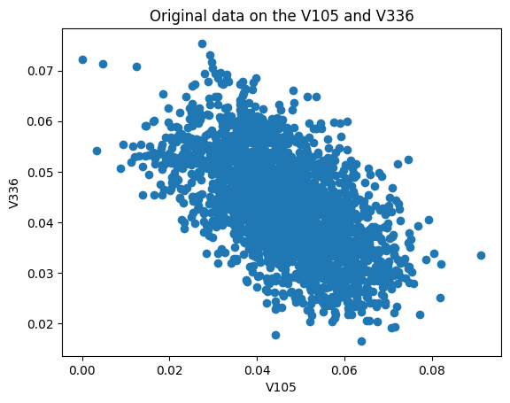

```python
# Scatter plot 2 - original data
plt.scatter(v1, v2)
plt.title(f"Original data on the V{indexes[0]} and V{indexes[1]}")
plt.xlabel(f"V{indexes[0]}")
plt.ylabel(f"V{indexes[1]}")
```

It's hard to identify visible clusters based on the plot of PC1 and PC2. The reason for this may be the too high dimensionalities of the dataset. There are too many features in the dataset and also possibly too much noise. The first two principle components therefore would not be sufficient enough to distinguish all these information.

### 9. Run k-means clustering on the transformed data from the previous problem

The number of dimensions of the transformed data is reduced and a lower dimensional dataset is a better choice for running k-means cluster. Below are a couple of reasons for that:

1. As the number of dimensions increases, the amount of data required to accurately represent the space grows exponentially. So a large number of dimensions can result in clusters appearing to be more spread out and less distinct, as well as leading to overfitting and increased computational complexity.
2. High-dimensional data requires more computational resources to perform clustering, especially when the size of the dataset is large. By reducing the dimensionality of the data using PCA, the computational complexity is also reduced, allowing the clustering algorithm to work more efficiently.
3. The reduced-dimensional data is easier to interpret. Lower-dimensional data can help to better understand the underlying structure of the data and make informed decisions based on the results.

### 10. Use the same k values again (4, 8, 16, 32, 64) to again generate an elbow plot

```python
df3 = k_means(klist, madelon_trans)
df3
```

|  | k | inertia | silhouette |
| --- | --- | --- | --- |
| 0 | 4 | 6.089687 | 0.062657 |
| 1 | 8 | 5.633053 | 0.048751 |
| 2 | 16 | 5.371189 | 0.031360 |
| 3 | 32 | 5.166732 | 0.020715 |
| 4 | 64 | 4.972685 | 0.013470 |

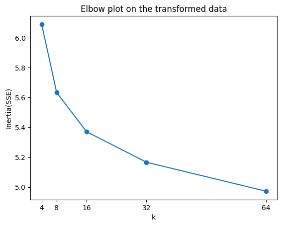

```python
# Elbow plot for the transformed data
inertia3 = df3[["inertia"]]

plt.plot(klist, inertia3, "-o", label = "transformed")
plt.xticks(klist)
plt.xlabel("k")
plt.ylabel("Inertia(SSE)")
plt.title("Elbow plot on the transformed data")
```

The optimal number of k still seem to be 32, which is not different from the choice made in the previous question.

### 11. Compare the SSE values plotted in this exercise to the previous plot before performing PCA.

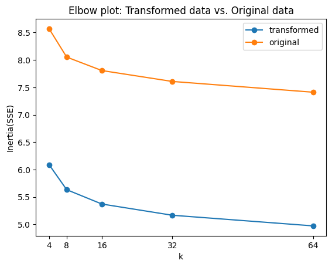

```python
# Compare the SSE values
plt.plot(klist, inertia3, "-o", label = "transformed")
plt.plot(klist, inertia, "-o", label = "original")
plt.xticks(klist)
plt.xlabel("k")
plt.ylabel("Inertia(SSE)")
plt.title("Elbow plot: Transformed data vs. Original data")
plt.legend()
```

The trends of the two plots are quite similar. It also explains why the choice of the number of k didn't change. But the abosule value SSE differs - after performing PCA, the overall SSE is significantly lower than the overall SSE before preforming PCA.

### 12. Create a scatter plot of PC 1 (x-axis) versus PC 2 (y-axis) for all of the transformed data points. Label the cluster centers and color-code by cluster assignment for the first 5 iterations of k = 32.

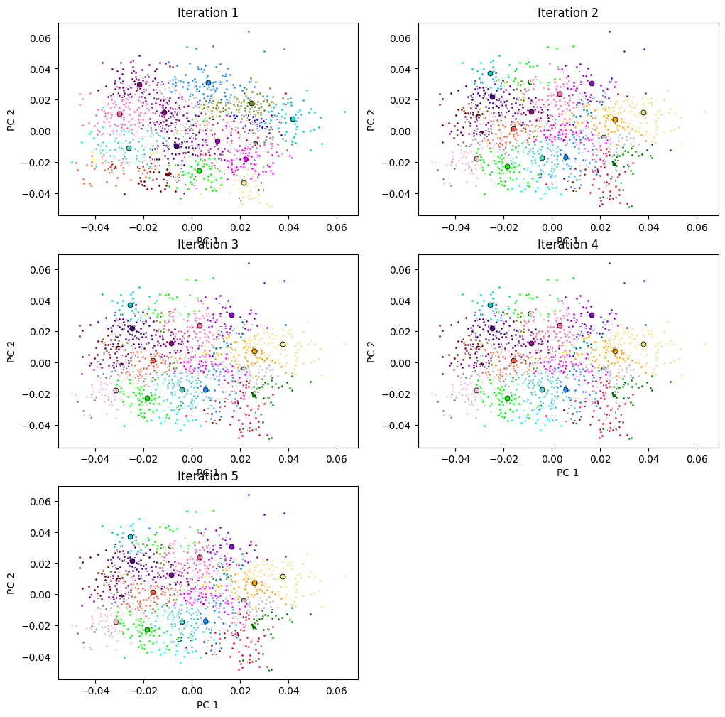

```python
# Perform K-means clustering with k = 32
n_clusters = 32
plt.figure(figsize = (12,12))
colors = ["#FF0000", "#00FF00", "#0000FF", "#FFFF00", "#FF00FF", "#00FFFF", "#800000", "#008000", "#000080", "#808000", "#800080", "#008080", "#C0C0C0", "#808080", "#FFA500", "#FFC0CB", "#800000", "#F0E68C", "#00FF7F", "#00FF00", "#6B8E23", "#FA8072", "#DC143C", "#FF6347", "#8B008B", "#FF00FF", "#1E90FF", "#4B0082", "#48D1CC", "#FF69B4", "#00CED1", "#9400D3"]

# Loop through the first 5 iteration
for i in range(1,6,1):
    model = KMeans(n_clusters=n_clusters, random_state=117, n_init=i).fit(madelon_trans)

    # Get the predicted label for each observation
    labels = model.fit_predict(madelon_trans)

    # Get the cluster centers
    cluster_centers = model.cluster_centers_

    # Extract the cluster centers for the first two principle components for visualization
    cluster_centers_2 = cluster_centers[:,:2]

    # Visualize the clustering process
    for k, col in zip(range(n_clusters), colors):
        my_members = labels == k
        cluster_center = cluster_centers_2[k]
        plt.subplot(3,2,i)
        plt.plot(madelon_trans[my_members, 0], madelon_trans[my_members, 1], "w", markerfacecolor=col, marker=".")
        plt.plot(cluster_center[0], cluster_center[1], "o", markerfacecolor=col, markeredgecolor = "k", markeredgewidth=.6, markersize = 5)
        plt.title(f"Iteration {i}")
        plt.xlabel("PC 1")
        plt.ylabel("PC 2")
```